# Where Are My Fans?

Sam Smith vs. Post Malone: Billboard, Spotify, and Twitter Weigh In

Heather MacDougall

Both Sam Smith and Post Malone are currently top ranked artists on Spotify, and they’ve both recently released new music. However, they have very different music styles. Here I wanted to see how they each differed within varying measures of artist popularity.

If you’re not sure who Sam Smith and Post Malone are, check out their music here!

### Sam Smith

[interactive chart not shown]

Born in 1992, Sam Smith has been described as a “distinctly emotive, soul-inspired” singer-songwriter, who cites Adele and Amy Winehouse as some of his major influences while growing up in London. In early September he released the single “Too Good at Goodbyes,” which debuted at 5 on the US Hot 100. Sam Smith is ranked 7th overall on Spotify.

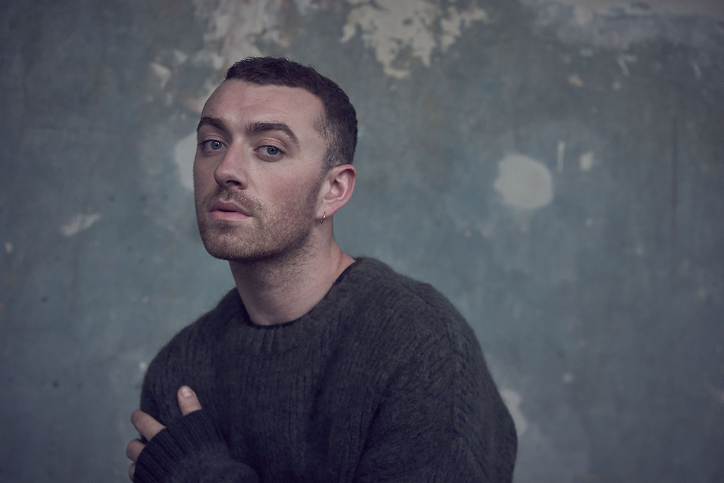

### Post Malone

Post Malone, born in 1995 as Austin Post, grew up in both Syracuse, New York, and outside of Dallas, Texas. His musical style is hard to nail down, as he himself describes his music as “genre-less”; however, others have described ist as “a melting pot of the country, grunge, hip-hop and R&B,” and the New York Times has described him as “an artist who toes the line between singing and rapping, and hip-hop and spooky electric folk.” Post Malone released the single “rockstar,” in September 2017, which currently holds the number one spot on the Billboard Hot 100. Post Malone is ranked third overall on Spotify.

[interactive chart not shown]

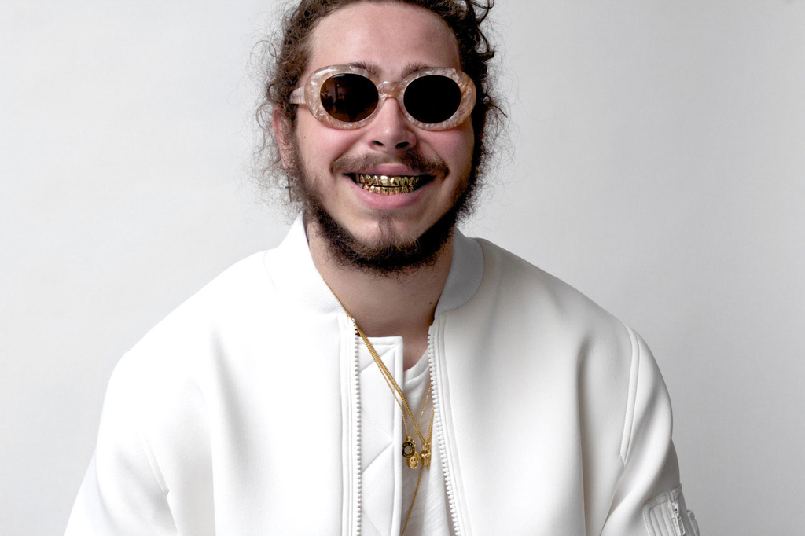

### Billboard

Here’s a chart of how Sam Smith’s and Post Malone’s songs have performed on the Billboard Hot 100 since release. rockstar has performed extremely well since release, while Too Good At Goodbyes has oscillated, despite never dipping below 16th.

[interactive chart not shown]

### Spotify

Spotify also publishes data on where it’s artists are most popular, which it measures by counting the cities with the most listeners. Here you can see Sam Smith is more internationally successful, while Post Malone finds success particularly in North America.

[interactive chart not shown]

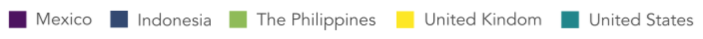

[interactive chart not shown]

### Twitter

Here’s an interactive map of tweets mentioning each artist. Hover over any point to read that tweet, and check or uncheck the boxes to select individual layers. You may also zoom in or out to any location.

This data was collected by scraping 18,000 tweets for each artist from Twitter, and then filtering down to just the tweets that included location data, a bit over 800 for each artist. The data was collected on November 29th, and so includes the few days before then. However, I was able to determine that Post Malone is much more tweeted about than Sam Smith, as his 18,000 only spanned November 26th to 29th, whereas Sam Smith’s covered the 23rd to the 29th.

Disclaimer: These tweets are unfiltered, and some may contain offensive or explicit content.

[interactive chart not shown]

### Conclusion

While it’s hard to make conclusions from this brief look into measures of artist popularity, there are a few takeaways. While Post Malone is more popular than Sam Smith overall, Post Malone is yet even more popular on Twitter than Sam Smith. In addition, Post Malone has very little international success, most of his audience base is in North America, whereas Sam Smith is much more international, and I would argue, has more recognition than Post Malone.

### Credits

Billboard, for Hot 100 ranking information. Spotify, for artist rankings, embedded music, and top cities information. Twitter, for tweets mentioning Sam Smith and Post Malone. Katie Jolly, for debugging assistance.